# Midterm Exam Part 2: Hands-on Coding Assignment

## Instructions

Type in your SUID in place of the zeros below and run the cell (click Ctrl + Enter):

```r
suid <- 921793530
```

The block of code below creates a custom data set for you to analyze. Your dataset is different from every other student’s dataset. The goal of this part of the exam is to write code and comments that address the research questions described below. The quality of your comments is critical to your success on this exam! You will only be submitting R code and there are several important results that require an explanation in plain language. Pay close attention to the research questions described below when writing your code and comments.

Do not modify any of the code, just run it as is:

```r
if (suid == 0) {cat("Please update your SUID (above) before running this code.")} else {cat(paste("Lyft/Uber Fare Comparison Study Number:",suid,"\n")); set.seed(suid); grp1id <- paste("Lyft",substr(as.hexmode(suid),1,2),sep="_"); grp2id <- paste("Uber",substr(as.hexmode(suid),1,2),sep="_"); ssize <- floor(runif(n=1,min=100,max=140)); driver <- 1:ssize; base <-round(rnorm(n=ssize,mean=25,sd=5), digits=2);lyft <- round(rowMeans(cbind(base, runif(ssize,min=15,max=35))),digits=2);if ((suid %% 2)==1) {uber <- round(rowMeans(cbind(base, runif(ssize,min=10,max=40))),digits=2) } else { uber <- round(rowMeans(cbind( base + rexp(n=ssize,rate=0.25), rnorm(n=ssize,mean=25,sd=5))),digits=2)}; testDF <- data.frame(driver,lyft,uber);cat(paste("Sample size for this study:",ssize)); t1 <- testDF[,3] + 0.25*rnorm(n=ssize, (mean(testDF[,3])),sd=5);t <-testDF[,2] + 1.1*rnorm(n=ssize,mean(testDF[,2]),sd=20); t[ t < 0] <- 0;t1[ t1 < 0] <- 0;testDF <- data.frame(driver,lyft,uber, t, t1);if ((suid %% 2)==1) {states <- c("New York", "Texas", "Texas", "Florida")}else {states <- c("California", "California","Texas", "Georgia") }; testDF$tmp1 <- sample(states, nrow(testDF), replace=TRUE); testDF$tmp2 <- testDF$tmp1;rm(states);names(testDF)[2]<-grp1id; names(testDF)[3]<-grp2id;names(testDF)[5]<-paste0(grp2id, "_distance");names(testDF)[4]<-paste0(grp1id, "_distance");names(testDF)[7]<-paste0(grp2id, "_state");names(testDF)[6]<-paste0(grp1id, "_state"); rm(base); rm(lyft); rm(uber); rm(ssize); rm(grp1id); rm(grp2id); rm(driver); rm(t); rm(t1)}
```

```
Lyft/Uber Fare Comparison Study Number: 921793530
Sample size for this study: 103
```

## Your Assignment: rYdZ Analysis

The code you just ran generates a unique dataframe called **testDF**. You can explore it by running, e.g. head(testDF). Columns 2 & 3 which only have the names of Lyft and Uber in them designate the **fare** for each company:

```r
head(testDF)
```

A data.frame: 6 × 7

|  | driver <int> | Lyft_36 <dbl> | Uber_36 <dbl> | Lyft_36_distance <dbl> | Uber_36_distance <dbl> | Lyft_36_state <chr> | Uber_36_state <chr> |
| --- | --- | --- | --- | --- | --- | --- | --- |
| 1 | 1 | 24.79 | 28.11 | 13.71397 | 35.74791 | California | California |
| 2 | 2 | 27.81 | 21.86 | 87.48669 | 26.91286 | Texas | Texas |
| 3 | 3 | 27.42 | 29.08 | 102.26207 | 34.97923 | California | California |
| 4 | 4 | 26.32 | 28.39 | 88.99817 | 35.99533 | California | California |
| 5 | 5 | 26.29 | 24.82 | 34.40039 | 31.52285 | Texas | Texas |
| 6 | 6 | 26.73 | 22.41 | 39.84793 | 29.47925 | Texas | Texas |

There is an upstart in the ride-sharing market: The new start-up firm **rYdZ** (pronounced “rides”) is driver-owned and operated. In addition to providing safe rides at competitive prices, the mission of **rYdZ** is to provide a working wage to **rYdZ** drivers. But the leadership team at **rYdZ** believes there is a problem: the two giants in the industry, **Lyft** and **Uber**, are coordinating to set prices for rides that are artificially low. The team at **rYdZ** has produced a data set of more than 100 fares offered to drivers from **Lyft** and **Uber**. Your job is to analyze this data set and infer whether there is some sort of coordination between **Lyft** and **Uber** to set prices, as well as understand if either is pricing based on miles driven, or perhaps, based on geography.

## Data Set Description:

Your data set contains **five variables**: The **ride number**, the **fare** (in dollars and cents) of a ride offered to a driver from Lyft, and the **distance** of that ride (in miles). There is also a **fare for a different ride** offered to a driver through Uber (and the **distance of that trip**). There are at least 100 observations (rows) in your dataset, and possibly more. Each observation was done at roughly the same time for Uber and Lyft (the data for the ride in a row was collected at roughly the same time).

## Research Questions (tasks to do):

1. Describe the fares provided by Lyft and Uber (separately) using descriptive statistics:

```r
summary(testDF) #the average fare of a lyft ride is $25.64, with a min of $15.22 and a max of $32.80
#the average fare of an Uber ride is $27.62, with a min of $19.06 and a max of $36.42
```

```
     driver         Lyft_36         Uber_36      Lyft_36_distance
 Min.   :  1.0   Min.   :15.22   Min.   :19.06   Min.   :  0.00
 1st Qu.: 26.5   1st Qu.:23.41   1st Qu.:24.58   1st Qu.: 33.90
 Median : 52.0   Median :26.30   Median :28.13   Median : 52.52
 Mean   : 52.0   Mean   :25.64   Mean   :27.62   Mean   : 53.36
 3rd Qu.: 77.5   3rd Qu.:28.10   3rd Qu.:30.18   3rd Qu.: 74.78
 Max.   :103.0   Max.   :32.80   Max.   :36.42   Max.   :110.80
 Uber_36_distance Lyft_36_state      Uber_36_state
 Min.   :25.03    Length:103         Length:103
 1st Qu.:31.48    Class :character   Class :character
 Median :34.24    Mode  :character   Mode  :character
 Mean   :34.45
 3rd Qu.:37.67
 Max.   :43.98
```

1. Describe the shape of the distribution for Lyft fares. Do the same for Uber fares:

```r
library(tidyverse)
```

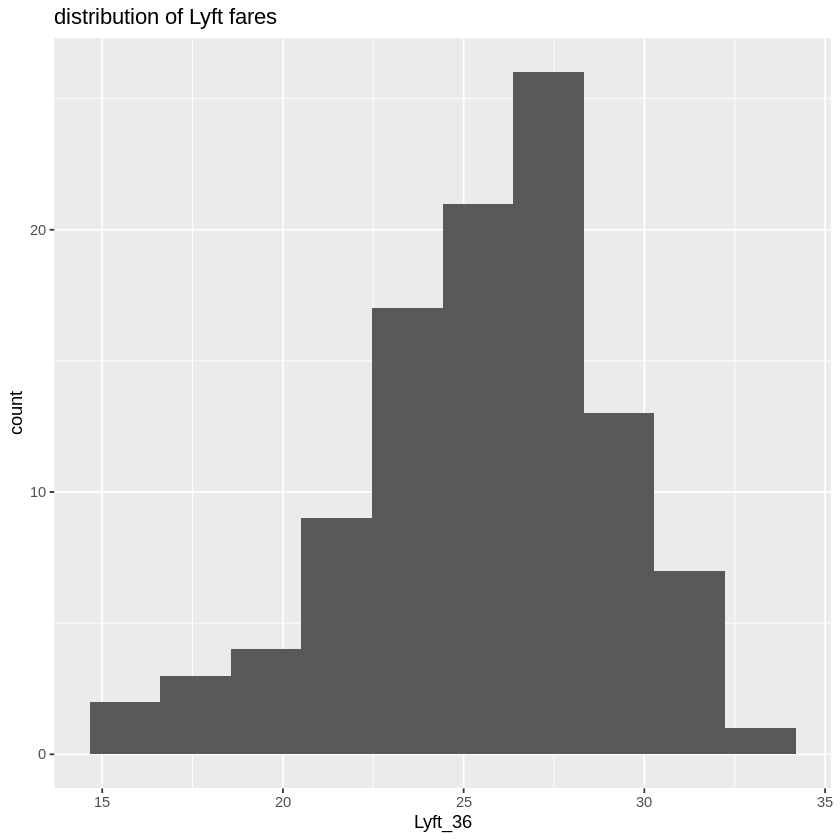

```r
ggplot(testDF)+
geom_histogram(aes(Lyft_36), bins = 10)+
ggtitle('distribution of Lyft fares') #lyft's distribution is roughly normal centered on the mean fare
```

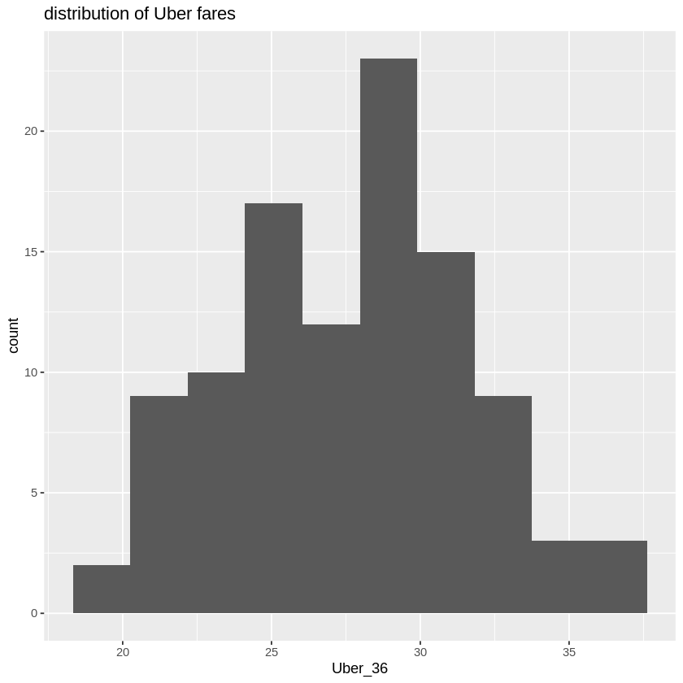

```r
ggplot(testDF)+
geom_histogram(aes(Uber_36), bins = 10)+
ggtitle('distribution of Uber fares') #uber has a generally normal distribution centered around the mean fare
```

1. Based on the fares offered by both companies, on average, which company is more expensive, Lyft or Uber? By how much?

```r
mean(testDF$Lyft_36)-mean(testDF$Uber_36) #on average, prices of Uber tend to be about $2 more expensive than those of Lyft
```

-1.9752427184466

1. Create a new variable that represents the difference in fares between Uber and Lyft for each observation (i.e., each row):

```r
testDF %>%
mutate(fare.diff = Uber_36 - Lyft_36) -> testDF
```

1. Describe the shape of the distribution for this new variable:

```r
summary(testDF$fare.diff)
```

```
   Min. 1st Qu.  Median    Mean 3rd Qu.    Max.
 -7.040  -0.720   2.130   1.975   4.545  12.410
```